# Simple to multiple regression

Statistics and Data Science II · Week 2

Jesper Lindmarker

## Today

**In the lecture**

1. A second predictor: **multiple regression**
2. Why a coefficient moves: **confounding**
3. The role of **time** in cause and effect
4. Interpreting the **full regression** table:
   - Ceteris paribus, R-squared, uncertainty, p-values

**In the lab**

1. New data: education and violence
2. From one predictor to two
3. Interpreting the regression table
4. Explaining why a coefficient moved
5. Calculating predictions

## Today’s question

> **Does staying in education protect against violent offending?**
- **The idea:** staying in school, rather than dropping out, could itself make it less likely that someone ends up in violent crime.
- **Why it matters:** if it does, keeping young people in school is also crime policy (Hjalmarsson, Holmlund and Lindquist 2015).

## Draw your assumptions

Exercise

- **Task:** on paper, draw **everything** that **you think** influences education, violent offending, or both.
- **Nodes and directed edges:** A node for each thing (variable), an edge from whatever affects it.
- **New: time order.** Nodes from left to right, in the order they happen.

We do this for 4 minutes.

## Nodes and edges, in time order

```
%%{init: {"theme":"base","themeVariables":{"fontFamily":"Source Sans 3, sans-serif","fontSize":"20px","primaryColor":"#ffffff","primaryTextColor":"#33383d","primaryBorderColor":"#858b91","lineColor":"#9aa0a6"},"flowchart":{"curve":"basis","nodeSpacing":12,"rankSpacing":140,"padding":6}}}%%
flowchart LR
  A --> X
  A --> Y
  B --> X
  C --> X
  C --> J
  D --> A
  D --> C
  E --> Y
  F --> E
  F --> B
  G --> X
  G --> Y
  H --> C
  I --> Y
  X --> Y
  Y --> J
  classDef main fill:#ffffff,stroke:#33383d,stroke-width:2.6px,color:#17181a;
  classDef other fill:#ffffff,stroke:#c9ccd0,stroke-width:1.4px,color:#858b91;
  class X,Y main;
  class A,B,C,D,E,F,G,H,I,J other;
```

time

**New this week:** each node sits where it happens in time, so every edge points **forward**: a cause comes before its effect. X is education, Y is violent offending.

## What did you draw?

# Variation left to explain

## Exam scores

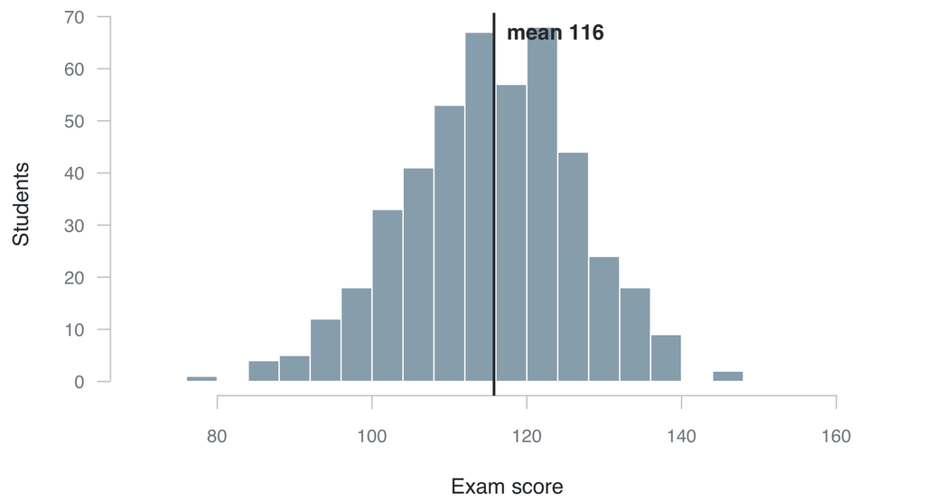

The 456 students with every value in the file. Scores from 77 to 145. Why do students get different scores?

## Predicting with the mean

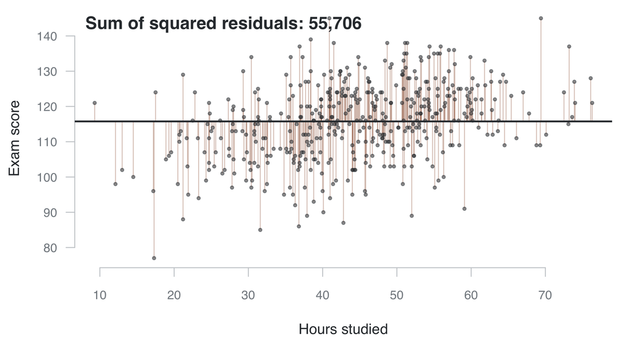

If we know nothing else, we predict the mean for everyone. The red lines are the residuals.

## Predicting with hours

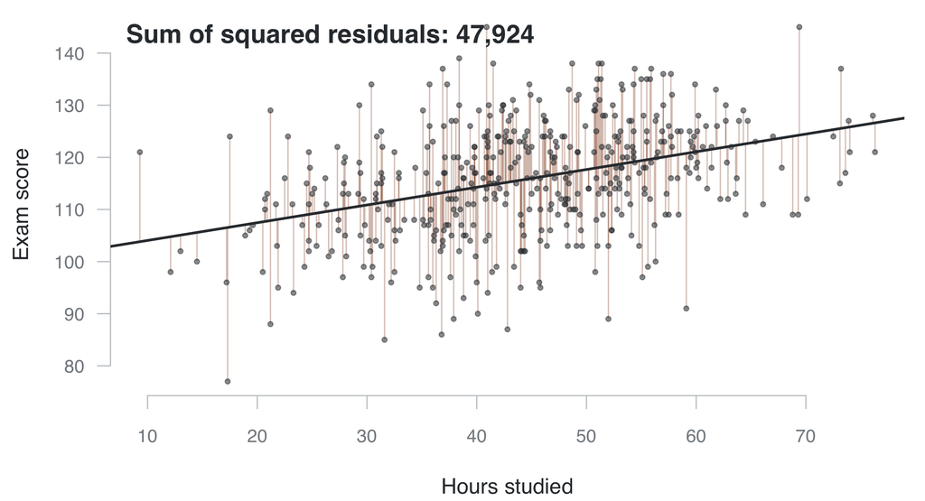

Last week’s model. Hours took away some of the residuals. Most of the variation is still there.

## Students who studied 40 hours

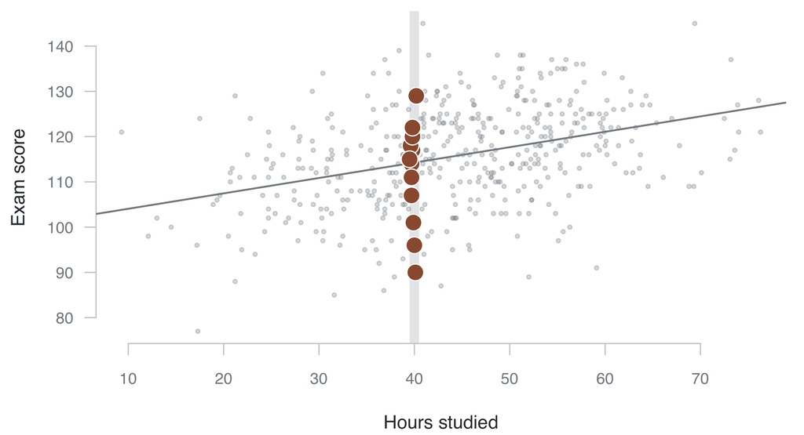

14 students studied between 39.5 and 40.5 hours. Their scores run from 90 to 129. Same hours, different scores.

## Students who studied 40 hours

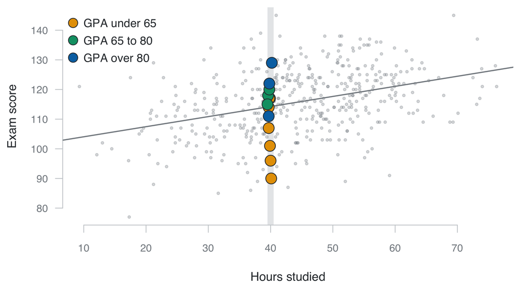

The same 14, coloured by previous GPA. The highest scores went to the highest GPAs.

## Every student

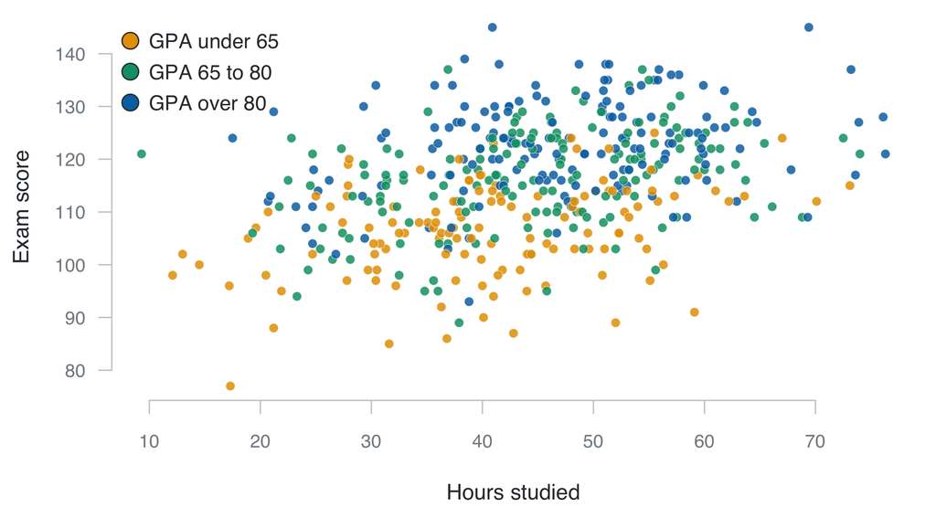

All 456. Students with a higher GPA score higher. They also study more.

# Could GPA improve the prediction?

## Two predictors in R

```r
m1 <- lm(exam_score ~ hours_studied, data = exam)
m2 <- lm(exam_score ~ hours_studied + previous_gpa, data = exam)
```

One more `+` and one more variable. Everything else is the same.

## Two predictors in R

```
Call:
lm(formula = exam_score ~ hours_studied, data = exam)

Residuals:
     Min       1Q   Median       3Q      Max
-29.7654  -6.5660   0.2107   6.8982  30.4280

Coefficients:
               Estimate Std. Error t value Pr(>|t|)
(Intercept)   100.65386    1.82431  55.174   <2e-16 ***
hours_studied   0.34030    0.03963   8.586   <2e-16 ***
---
Signif. codes:  0 '***' 0.001 '**' 0.01 '*' 0.05 '.' 0.1 ' ' 1

Residual standard error: 10.27 on 454 degrees of freedom
Multiple R-squared:  0.1397,    Adjusted R-squared:  0.1378
F-statistic: 73.72 on 1 and 454 DF,  p-value: < 2.2e-16
```

## Two predictors in R

```
Call:
lm(formula = exam_score ~ hours_studied + previous_gpa, data = exam)

Residuals:
     Min       1Q   Median       3Q      Max
-27.6294  -5.5828   0.2299   5.3861  26.1088

Coefficients:
              Estimate Std. Error t value Pr(>|t|)
(Intercept)   76.52508    2.10517   36.35  < 2e-16 ***
hours_studied  0.21709    0.03269    6.64 8.98e-11 ***
previous_gpa   0.40547    0.02545   15.93  < 2e-16 ***
---
Signif. codes:  0 '***' 0.001 '**' 0.01 '*' 0.05 '.' 0.1 ' ' 1

Residual standard error: 8.234 on 453 degrees of freedom
Multiple R-squared:  0.4486,    Adjusted R-squared:  0.4462
F-statistic: 184.3 on 2 and 453 DF,  p-value: < 2.2e-16
```

## Residuals

|  | Sum of squared residuals |
| --- | --- |
| The mean alone | 55,706 |
| Model 1: hours | 47,924 |
| Model 2: hours and GPA | 30,716 |

Sum of squares are not saved in the lm() model object. It can be retreived from the residuals or using deviance().

## How R arrives at the coefficients

- R picks the coefficients with the **smallest** sum of squared residuals. This is **least squares**.
- For Model 2 that sum is 30,716. Any other pair gives more.

**For the curious**: The calculation has a closed form solution, which you can read on [Wikipedia](https://en.wikipedia.org/wiki/Proofs_involving_ordinary_least_squares).

# Prediction or understanding

## Two reasons to add a variable

**To predict**

- Which cancer patients survive, from age, treatment and tumour stage
- Who is at risk of long-term unemployment
- Who is likely to buy a product
- The next word in a sentence

**To understand**

- Does education reduce crime?
- Does social media use cause depression?
- Does unemployment lead to worse health?
- Does studying more raise exam scores?

## Prediction or understanding

|  | Model 1 | Model 2 |
| --- | --- | --- |
| Hours studied | 0.34 | 0.22 |
| Previous GPA |  | 0.41 |

- To **predict**, Model 2 is better: its predictions are closer.
- To **understand**, we ask something else: what does one more hour of study do to the exam score? Is it 0.34 or 0.22?

## Bias

- Suppose there is a **true average effect** of one more hour of study.
- An estimate is **biased** when it misses that true effect **for a reason**, not by chance.

## Six reasons

| # | Reason | Why that shows up as an association |
| --- | --- | --- |
| 1 | X causes Y | Change X and Y follows, so the two move together |
| 2 | Y causes X | Change Y and X follows, so the two move together |
| **3** | **Something else causes both** | **A third thing moves both at once** |
| 4 | Who is in the data? | Selection into the sample leaves a pattern among those included |
| 5 | How it was measured | The measurements move together even when they in reality do not |
| 6 | Chance, or too small to matter | In any finite sample, two unrelated things still show something |

Reason 3 is a source of bias, and the one more variables can do something about.

# Confounding, a common cause

## Why the coefficient moved

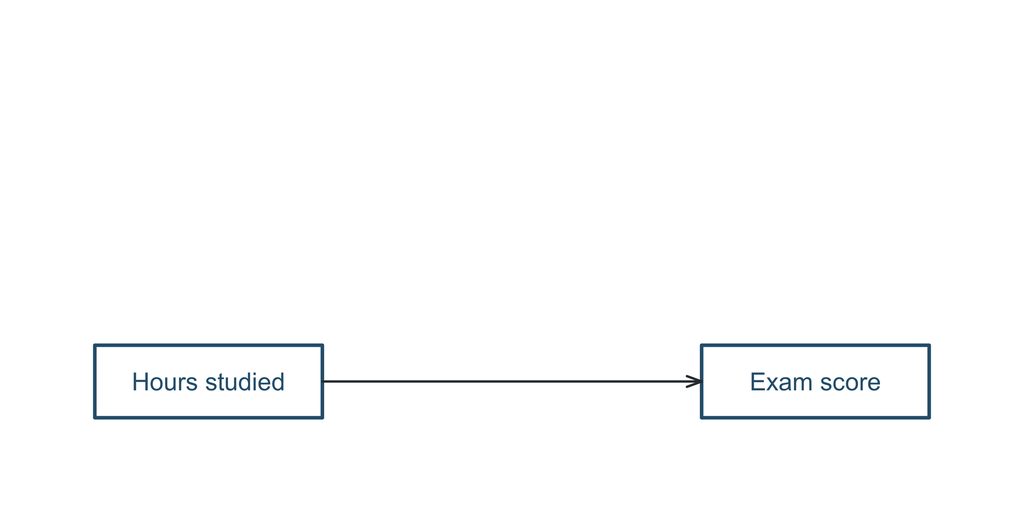

Model 1 sees only hours and the score.

## Why the coefficient moved

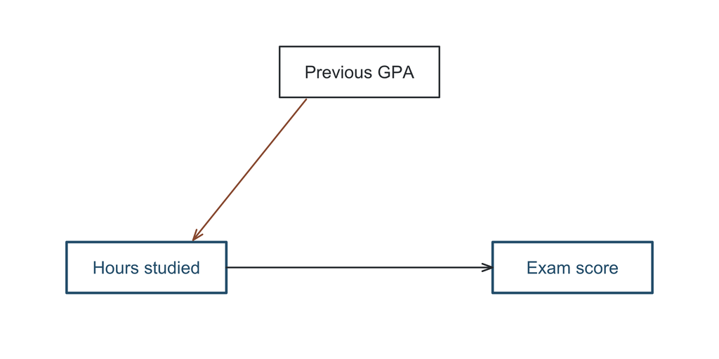

Students with a higher GPA study more.

## Why the coefficient moved

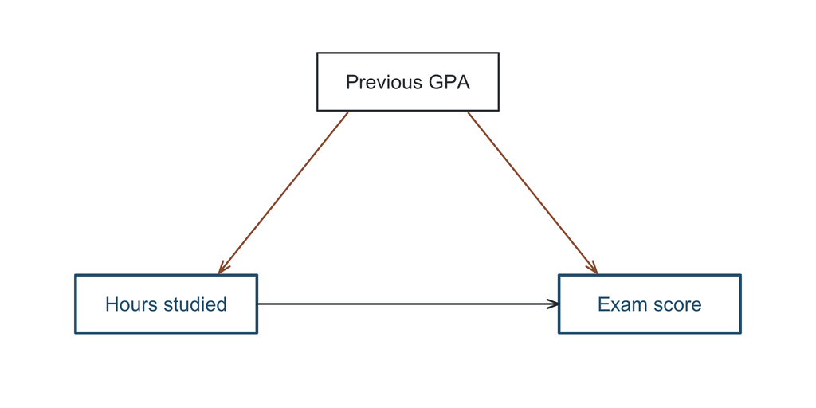

Students with a higher GPA also score higher. It’s a common cause of hours studied and exam score.

## Why the coefficient moved

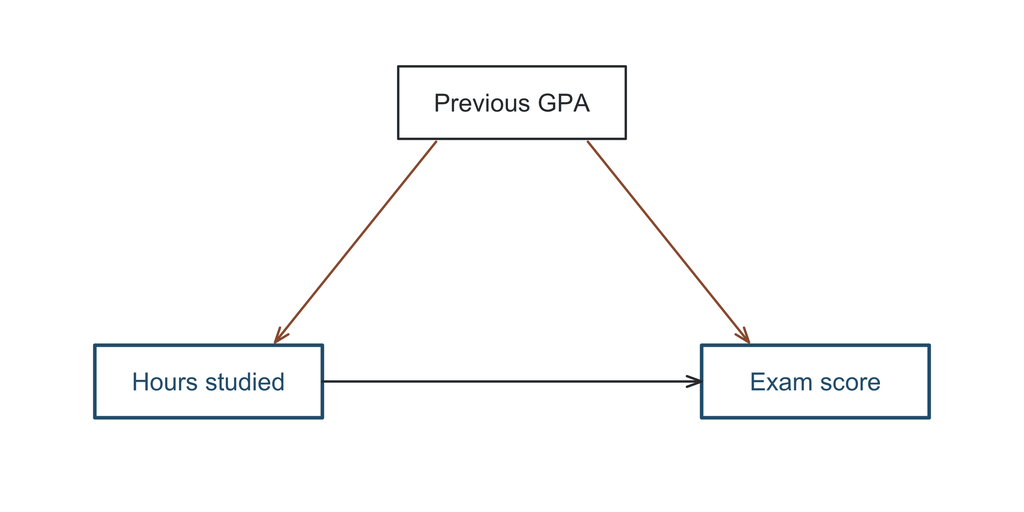

In Model 1, hours got the credit for both arrows. Model 2 compares students with the same GPA, and hours keeps only its own part.

## Confounding

- When a variable affects **both** the predictor and the outcome, omitting it biases the association.
- This is called **confounding**.
- In our case we would call GPA a **confounder**.

Leaving out a confounder is also called **omitted variable bias**.

# Cause and time

## The other way round?

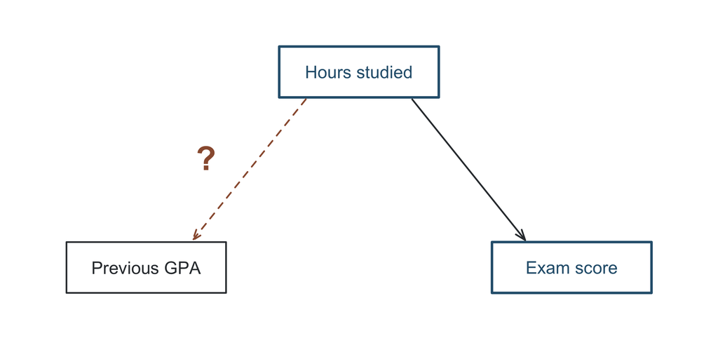

Studying raises grades too. Could hours be the common cause of GPA and the exam score?

## Billiard balls

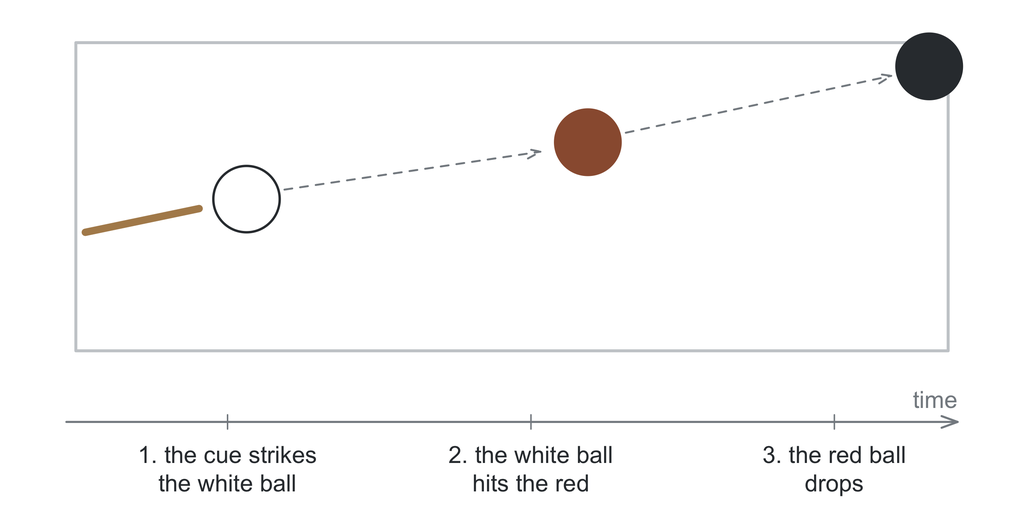

We see the white ball move, then the red. We never see the cause, only the order (Hume, 1748). A cause comes before what it causes.

## A confounder comes first

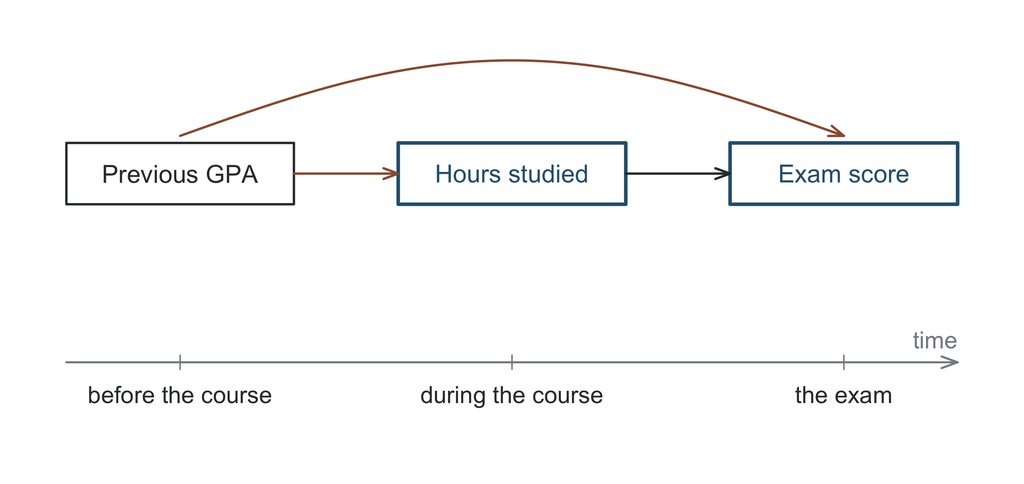

Previous GPA was earned before the course, so the hours studied for this exam cannot have changed it. A confounder comes before the predictor.

# Let’s play: Spot the confounder!

## Ice cream and drownings

Over the year, ice cream sales and drownings rise and fall together. Does eating ice cream cause drownings?

- What’s the common cause?
- **Summer.** Warm weather means more ice cream and more swimming.

## Firefighters and damage

The more firefighters sent to a fire, the more damage the fire does. Is it actually the firefighters causing the additional damage?

- What’s the common cause?
- **The size of the fire.** A big fire gets more firefighters and does more damage.

## Grey hair and heart disease

People with grey hair have more heart disease. Should an epidemiologist examine if there is a causal link between the two?

- What’s the common cause?
- **Age.**

## Shoe size and reading

```
Call:
lm(formula = reading_score ~ shoe_size, data = kids)

Residuals:
     Min       1Q   Median       3Q      Max
-28.1516  -8.0337   0.1248   7.6695  31.3931

Coefficients:
             Estimate Std. Error t value Pr(>|t|)
(Intercept) -125.3689     9.9937  -12.54   <2e-16 ***
shoe_size      5.5447     0.2711   20.46   <2e-16 ***
---
Signif. codes:  0 '***' 0.001 '**' 0.01 '*' 0.05 '.' 0.1 ' ' 1

Residual standard error: 10.89 on 198 degrees of freedom
Multiple R-squared:  0.6788,    Adjusted R-squared:  0.6772
F-statistic: 418.5 on 1 and 198 DF,  p-value: < 2.2e-16
```

## Shoe size and reading, with age

```
Call:
lm(formula = reading_score ~ shoe_size + age, data = kids)

Residuals:
     Min       1Q   Median       3Q      Max
-24.0123  -4.7663  -0.1787   5.2838  19.6048

Coefficients:
            Estimate Std. Error t value Pr(>|t|)
(Intercept) -10.2732    11.3184  -0.908    0.365
shoe_size     0.2664     0.4438   0.600    0.549
age           8.1390     0.6130  13.278   <2e-16 ***
---
Signif. codes:  0 '***' 0.001 '**' 0.01 '*' 0.05 '.' 0.1 ' ' 1

Residual standard error: 7.932 on 197 degrees of freedom
Multiple R-squared:  0.8305,    Adjusted R-squared:  0.8288
F-statistic: 482.6 on 2 and 197 DF,  p-value: < 2.2e-16
```

Holding age constant, shoe size goes with 0.27 reading points instead of 5.54.

## Spurious

- This association was **“spurious”**, it wasn’t real.
- **all** of it came from age.
- Hours and GPA were different, because 0.22 remained.

## Confounding, so far

- A confounder affects **both** the predictor and the outcome.
- It comes **before** the predictor in time.
- Leaving it out **biases** the coefficient. Adding it **moves** the coefficient making it **less biased**.
- We can only add the confounders we have **measured**.
- If we could measure every confounder, we would get the **true effect** of the predictor.

# Reading the regression table in multiple regression

## What R prints

```
Call:
lm(formula = exam_score ~ hours_studied + previous_gpa, data = exam)

Residuals:
     Min       1Q   Median       3Q      Max
-27.6294  -5.5828   0.2299   5.3861  26.1088

Coefficients:
              Estimate Std. Error t value Pr(>|t|)
(Intercept)   76.52508    2.10517   36.35  < 2e-16 ***
hours_studied  0.21709    0.03269    6.64 8.98e-11 ***
previous_gpa   0.40547    0.02545   15.93  < 2e-16 ***
---
Signif. codes:  0 '***' 0.001 '**' 0.01 '*' 0.05 '.' 0.1 ' ' 1

Residual standard error: 8.234 on 453 degrees of freedom
Multiple R-squared:  0.4486,    Adjusted R-squared:  0.4462
F-statistic: 184.3 on 2 and 453 DF,  p-value: < 2.2e-16
```

## What to read

[output not shown]

1. **Estimate:** the intercept, and one coefficient per predictor
2. **Multiple R-squared:** how much of the variation the model accounts for
3. **Std. Error:** how sure we can be of each estimate
4. **t value** and **Pr(>|t|)**: could the true coefficient be zero?

# Coefficients in multiple regression

## Several predictors

```
Coefficients:
              Estimate Std. Error t value Pr(>|t|)
(Intercept)   76.52508    2.10517   36.35  < 2e-16 ***
hours_studied  0.21709    0.03269    6.64 8.98e-11 ***
previous_gpa   0.40547    0.02545   15.93  < 2e-16 ***
---
Signif. codes:  0 '***' 0.001 '**' 0.01 '*' 0.05 '.' 0.1 ' ' 1

Residual standard error: 8.234 on 453 degrees of freedom
Multiple R-squared:  0.4486,    Adjusted R-squared:  0.4462
```

With one predictor, hours’ coefficient compares students who differ in hours. With two, it compares students who differ in hours **and have the same GPA**. That changes how every coefficient is read.

## Multiple regression as an equation

$$\begin{aligned} \text{Last week:} \quad \widehat{\text{exam score}} &= b_0 + b_1 \cdot \text{hours} \\[0.4em] \text{Today:} \quad \widehat{\text{exam score}} &= b_0 + b_1 \cdot \text{hours} + b_2 \cdot \text{GPA} \\[0.4em] \text{Model 2:} \quad \widehat{\text{exam score}} &= 76.53 + 0.217 \cdot \text{hours} + 0.405 \cdot \text{GPA} \end{aligned}$$

## The intercept

Set every predictor to zero:

$$\widehat{\text{exam score}} = 76.53 + 0.217 \cdot 0 + 0.405 \cdot 0 = 76.53$$

- **76.5** is the predicted score for a student with zero hours of study **and** a GPA of zero.
- Some might have studied 0 hours, but no one had a GPA of 0. The intercept is **not** a prediction for any real student.
- The intercept **might or might not have meaning** in it’s interpretation (this is usually an exam question)

# Ceteris paribus

All else equal

## Holding GPA constant

**Write it like this**

**Holding previous GPA constant**, a one-hour increase in hours studied is associated with an average change of **0.22 points** in exam score.

Also said as:

- Among students with the same GPA…
- Comparing two students who differ in hours studied, but not in GPA…
- All else equal…

## Why, with the equation

Two students with a GPA of 70, who studied 41 and 40 hours:

$$\begin{aligned} 76.53 + 0.217 \cdot \mathbf{41} + 0.405 \cdot 70 &= 113.81 \\ 76.53 + 0.217 \cdot \mathbf{40} + 0.405 \cdot 70 &= 113.59 \end{aligned}$$

- The difference is **0.217, hours’ coefficient**.
- The GPA part is the same for both: “held constant”

## Why, with the plot

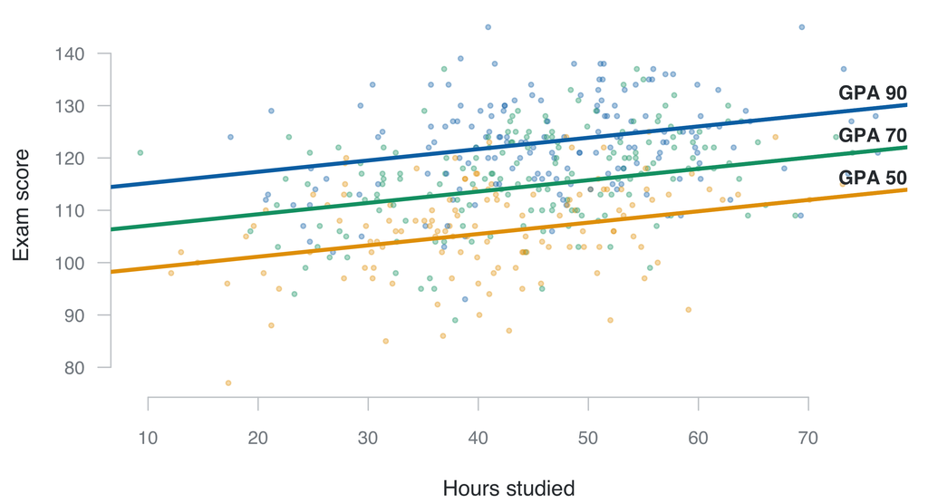

Model 2 drawn at GPA 50, 70 and 90. Every line has the slope 0.22: the slope **within** a GPA level.

## The GPA coefficient

Read the same way, with **hours held constant**.

## The general form

> **Holding [the other variables] constant,** a one-[unit] increase in [x] is associated with an average change of [b] [units of y] in [y].

> **Comparing two [units] who differ by one [unit] in [x], but have the same [other variables],** the one with more [x] is predicted to have [b] more [y], on average.

The first part, from Week 1, stays the same. What is new is in bold.

## Write it like this

**Write it like this**

Holding previous GPA constant, a one-hour increase in hours studied is associated with an average change of **0.22 points** in exam score.

**Another phrasing**

Comparing two students with the same previous GPA who differ by one hour of study, the one who studied more is predicted to score 0.22 points higher, on average.

# R-squared

## R-squared in the table

```
Coefficients:
              Estimate Std. Error t value Pr(>|t|)
(Intercept)   76.52508    2.10517   36.35  < 2e-16 ***
hours_studied  0.21709    0.03269    6.64 8.98e-11 ***
previous_gpa   0.40547    0.02545   15.93  < 2e-16 ***
---
Signif. codes:  0 '***' 0.001 '**' 0.01 '*' 0.05 '.' 0.1 ' ' 1

Residual standard error: 8.234 on 453 degrees of freedom
Multiple R-squared:  0.4486,    Adjusted R-squared:  0.4462
```

How much better does the model predict the exam scores than the mean alone?

## Better than the mean

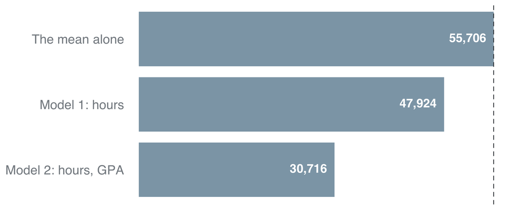

R-squared = 1 − the model’s sum of squared residuals ÷ the mean’s  
Model 1: 1 − 47,924 / 55,706 = **0.14** · Model 2: 1 − 30,716 / 55,706 = **0.45**

## R-squared in a sentence

**Write it like this**

Hours studied and previous GPA together account for **45%** of the variation in exam scores.

> [The predictors] account for **[R-squared × 100]%** of the variation in [y].

Model 1, hours alone: 14%.

## Some points about R-squared

- R-squared measures **prediction**.
- The shoe-size model had an R-squared of 0.68, for an association that was all age.
- A higher R-squared means better predictions. It does **not** mean a less biased coefficient.

Low R-squared does not mean the study is bad, and high R-squared does not mean the study is good. Values as low as 0.01-0.1 are reported in top journals.

# How sure are we?

## Uncertainty in the table

```
Coefficients:
              Estimate Std. Error t value Pr(>|t|)
(Intercept)   76.52508    2.10517   36.35  < 2e-16 ***
hours_studied  0.21709    0.03269    6.64 8.98e-11 ***
previous_gpa   0.40547    0.02545   15.93  < 2e-16 ***
---
Signif. codes:  0 '***' 0.001 '**' 0.01 '*' 0.05 '.' 0.1 ' ' 1

Residual standard error: 8.234 on 453 degrees of freedom
Multiple R-squared:  0.4486,    Adjusted R-squared:  0.4462
```

Our coefficients come from one sample of students. Students vary, so another sample would give slightly different coefficients. We cannot be completely sure of them. The standard error says how sure we can be.

## Which would you trust more?

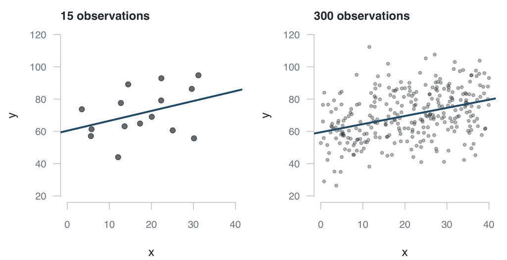

Two samples from the same world, made-up numbers. Which slope would you trust more?

## Which would you trust more?

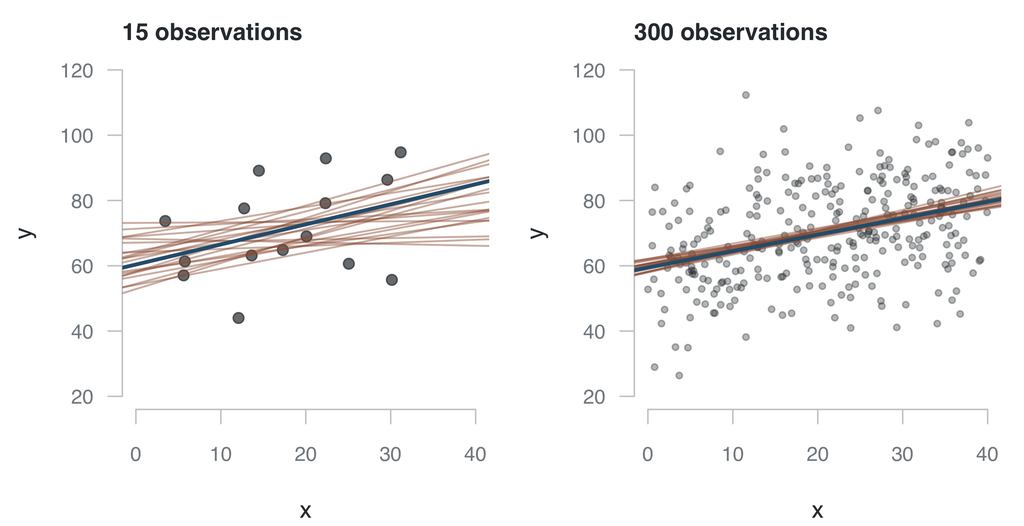

The red lines are twenty new samples of the same size. With more observations, the slope changes less from sample to sample.

## Which would you trust more?

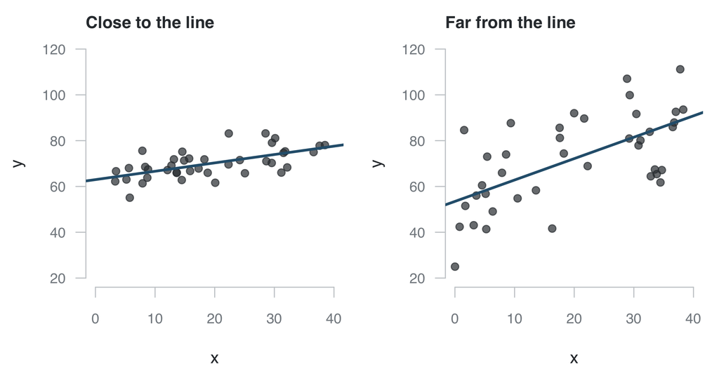

The same number of observations. Which slope would you trust more now?

## Which would you trust more?

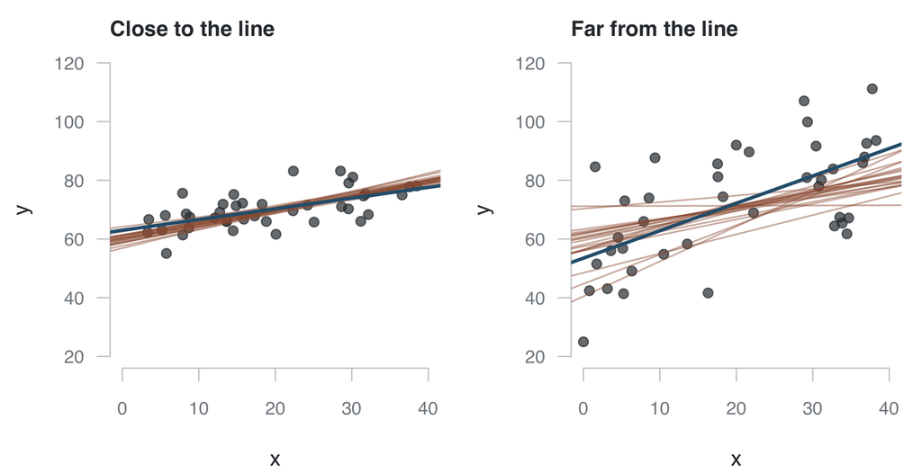

With less scatter around the line, the slope changes less from sample to sample.

## What makes an estimate more certain?

- **More observations**
- **Less variation** around the line
- Both make the estimate change less from one sample to the next.

## Other samples of students

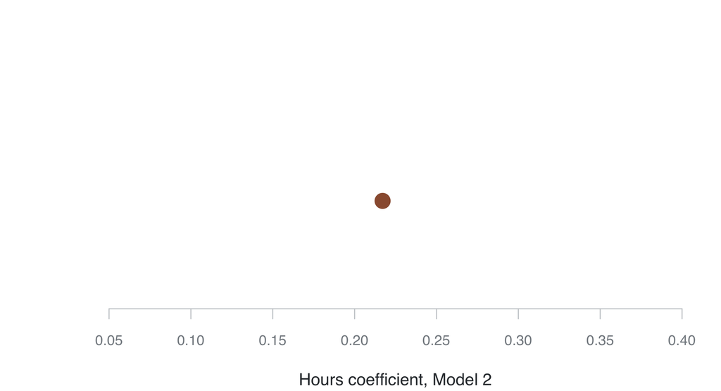

Our sample: 0.22. The data are simulated, so we can draw new students from the same world and fit Model 2 again.

## Other samples of students

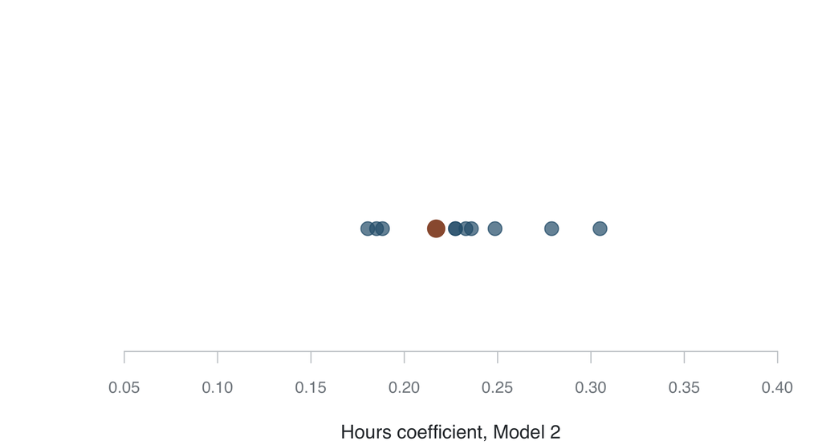

Ten new samples, ten different estimates.

## Other samples of students

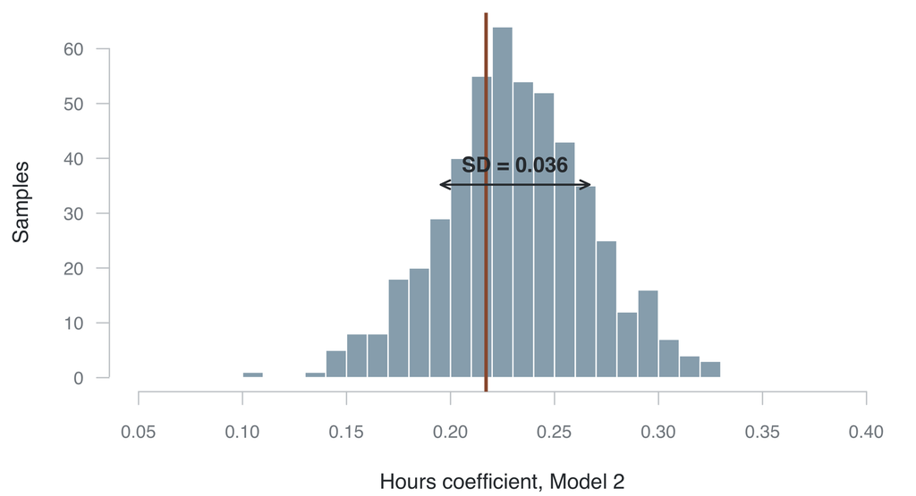

500 new samples. This spread of estimates is the coefficient’s **sampling distribution**. Its standard deviation is 0.036.

## The standard error

**The standard error**

The standard deviation of the coefficient’s sampling distribution: how much the estimate would typically differ from one sample to the next.

- R estimates the spread from it: **0.033**. The 500 samples gave 0.036.

## The 95% confidence interval

The estimate, plus and minus two standard errors:

- 0.217 ± 2 × 0.033 = **0.15 to 0.28**
- `confint(m2)` says 0.15 to 0.28.

**The 95% confidence interval**

If we drew many samples and built the interval this way each time, 95% of the intervals would contain the coefficient we would get with everyone in the population.

## The general form, grown

> **Holding [the other variables] constant,** a one-[unit] increase in [x] is associated with an average change of [b] [units of y] in [y] **(95% CI [lo] to [hi])**.

**Write it like this**

Holding previous GPA constant, a one-hour increase in hours studied is associated with an average change of **0.22 points** in exam score (95% CI 0.15 to 0.28).

# p-values and testing

## p-values in the table

```
Coefficients:
              Estimate Std. Error t value Pr(>|t|)
(Intercept)   76.52508    2.10517   36.35  < 2e-16 ***
hours_studied  0.21709    0.03269    6.64 8.98e-11 ***
previous_gpa   0.40547    0.02545   15.93  < 2e-16 ***
---
Signif. codes:  0 '***' 0.001 '**' 0.01 '*' 0.05 '.' 0.1 ' ' 1

Residual standard error: 8.234 on 453 degrees of freedom
Multiple R-squared:  0.4486,    Adjusted R-squared:  0.4462
```

Could hours’ true coefficient be zero, and our 0.22 only the luck of this sample? The last two columns test that.

## A test, as in SDS I

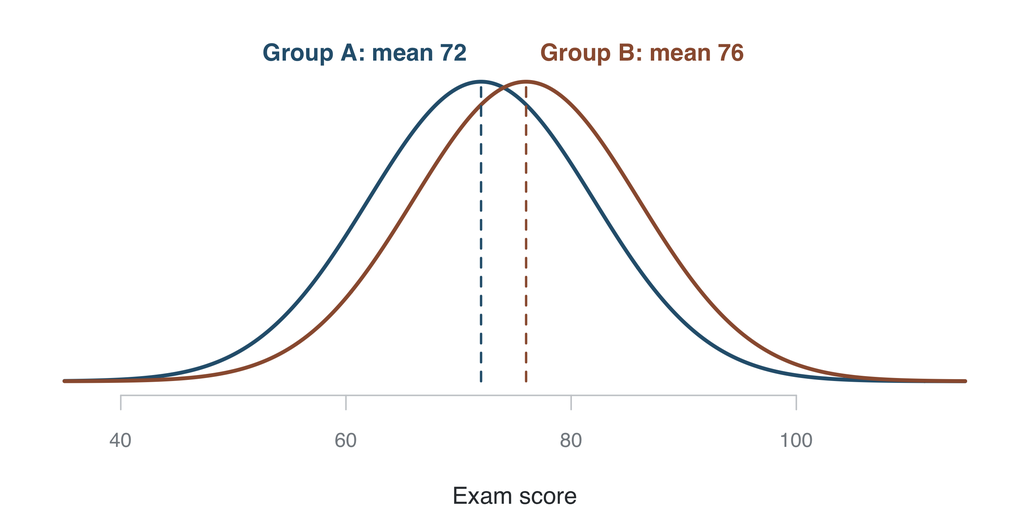

In SDS I, a t-test compared two groups. Their means differ by 4 points. The **null hypothesis**: the true difference is **zero**, and the 4 points are chance.

## The same test for a coefficient

- Our estimate is 0.22. Could hours’ **true coefficient be zero**, and 0.22 only chance?
- For a coefficient, the null hypothesis is almost always that it is **zero**: no association, with the other variables held constant.
- To find out, we ask what the estimates would look like **if the null were true**.

## If hours did nothing

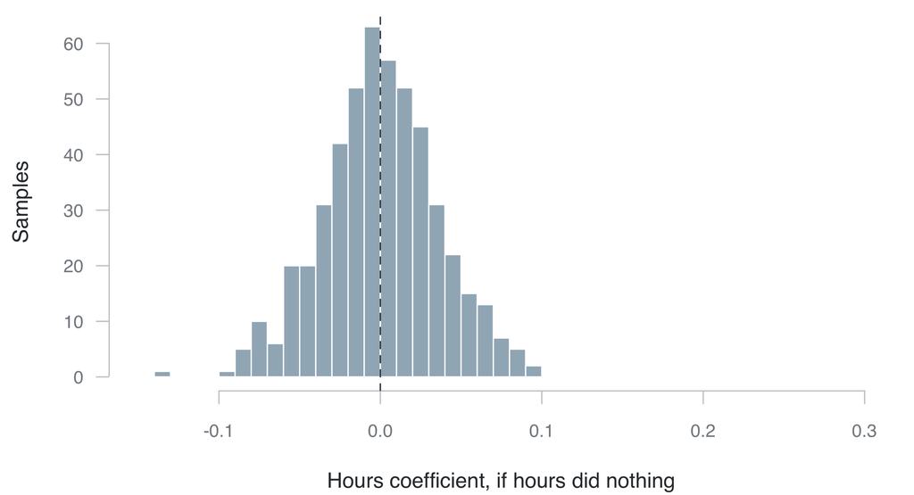

If hours’ true coefficient were zero, estimates from other samples would spread around zero like this. The spread is the **standard error**, about 0.03.

## If our estimate were 0.02

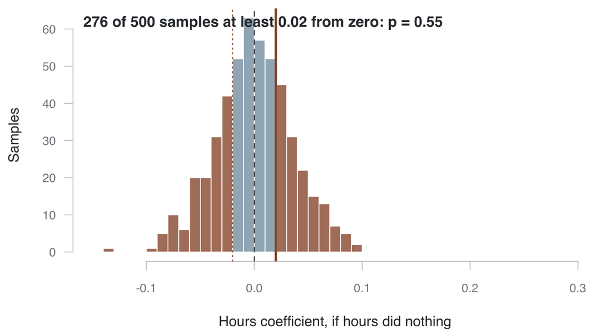

The red bars are the samples at least as far from zero as 0.02. An estimate like that would be **common** if hours did nothing: **p = 0.55**.

## If our estimate were 0.05

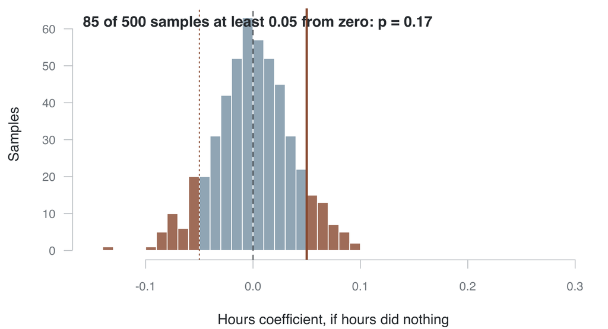

Further out, fewer samples. **p = 0.17**.

## If our estimate were 0.07

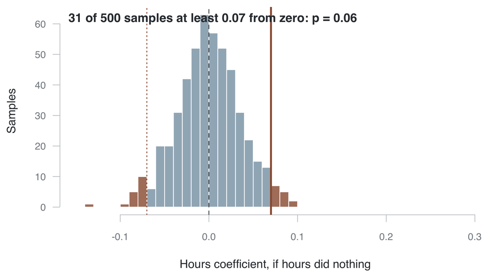

Only 31 of 500 samples get this far from zero if hours did nothing: **p = 0.06**, close to 0.05.

## Where ours lands

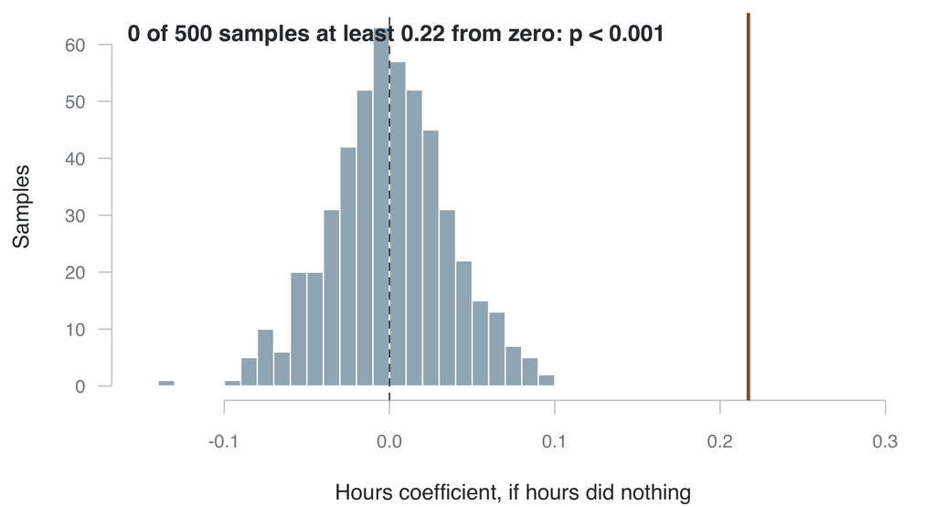

Our 0.22. **None** of the 500 samples gets that far from zero. R prints p = 9e-11.

## The p-value

**The p-value**

If the true coefficient were zero, the share of samples that would give an estimate at least as far from zero as ours.

- **Large p:** an estimate like ours would be common even if the true coefficient were zero.
- **Small p:** it would be rare. We then **reject** the null hypothesis.

## The t value

- As in SDS I: the **estimate divided by its standard error**.
- How many standard errors is 0.217 from zero?
- 0.217 / 0.033 = 6.6. The t column says 6.64.

## Five percent and the stars

- By convention, p below 0.05 is called **statistically significant**. The stars in a table mark it.
- p crosses 0.05 at about **two standard errors** from zero, close to our third made-up estimate.

## The ASA statement

In 2016 the American Statistical Association issued a statement on p-values (Wasserstein and Lazar 2016). Among its points:

- A p-value is **not** the probability that the null hypothesis is true, or that the result is due to chance.
- A p-value does **not** measure the size of an effect or how much it matters.
- Conclusions should **not rest only** on whether p passes a threshold such as 0.05.

## What to do instead

- Report the **estimate with its interval**, and say what size would matter.
- Report the **p-value itself**, not only the stars.
- p above 0.05 does **not** mean there is no association. p below 0.05 does **not** mean it is large.
- The editors of the ASA’s journal went further in 2019: stop saying “statistically significant” (Wasserstein, Schirm and Lazar 2019).

# Today

## What to take to the exam

**Be able to say what these are**

- Bias, confounding, a confounder
- A spurious association
- Ceteris paribus, two ways
- R-squared, and what it does not say
- A standard error
- What 95% refers to, and what a p-value is

**Be able to do these**

- **Explain why a coefficient moved**
- Place a confounder in time
- Say what least squares makes smallest
- Predict $\widehat y$ and a residual by hand
- Build an interval from b and SE, and read a p-value
- **Write the sentence with its interval**

# In the lab

Your drawing from today meets the crime data. One predictor, read column by column, then a second.